## # Коан об инcтрументах для простой регрессии

> Инструментальные переменные решают проблему эндогенности регрессоров. Так как эндогенность приводит к смещенности и несостоятельности МНК-оценок, коэффициенты регрессоров являются неточными. Вводя в анализ инструментальные переменные, коррелирующие с регрессором, эндогенность часто удается устранить.

Рассмотрим, как метод инструментальных переменных реализуется на R, Python и в Stata.

## На R

Загружаем нужные пакеты:

```r
library(ggplot2) # Для построения графиков
library(gridExtra) # Для визуализации
library(dplyr) # Для работы с данными
library(skimr) # Для изучения данных
library(Ecdat) #  Для работы с IV
library(AER) #  Для работы с IV
library(ggcorrplot) # Для построения коррелограмы. Для установки: devtools::install_github("kassambara/ggcorrplot")
```

Загружаем данные по продаже недвижимости **Housing**, изучаем их строение, визуализируем:

```r
skim(Housing)
```

```
Skim summary statistics
 n obs: 546
 n variables: 12

── Variable type:factor ───────────────────────────────────────────────────────────────────────────────────────────────────────────
 variable missing complete   n n_unique               top_counts ordered
    airco       0      546 546        2 no: 373, yes: 173, NA: 0   FALSE
 driveway       0      546 546        2  yes: 469, no: 77, NA: 0   FALSE
 fullbase       0      546 546        2 no: 355, yes: 191, NA: 0   FALSE
    gashw       0      546 546        2  no: 521, yes: 25, NA: 0   FALSE
 prefarea       0      546 546        2 no: 418, yes: 128, NA: 0   FALSE
  recroom       0      546 546        2  no: 449, yes: 97, NA: 0   FALSE

── Variable type:numeric ──────────────────────────────────────────────────────────────────────────────────────────────────────────
 variable missing complete   n     mean       sd    p0   p25   p50   p75
  bathrms       0      546 546     1.29     0.5      1     1     1     2
 bedrooms       0      546 546     2.97     0.74     1     2     3     3
 garagepl       0      546 546     0.69     0.86     0     0     0     1
  lotsize       0      546 546  5150.27  2168.16  1650  3600  4600  6360
    price       0      546 546 68121.6  26702.67 25000 49125 62000 82000
  stories       0      546 546     1.81     0.87     1     1     2     2
   p100     hist
      4 ▇▁▂▁▁▁▁▁
      6 ▁▃▁▇▂▁▁▁
      3 ▇▁▃▁▁▃▁▁
  16200 ▅▇▆▂▁▁▁▁
 190000 ▃▇▅▂▁▁▁▁
      4 ▇▁▇▁▁▂▁▂
```

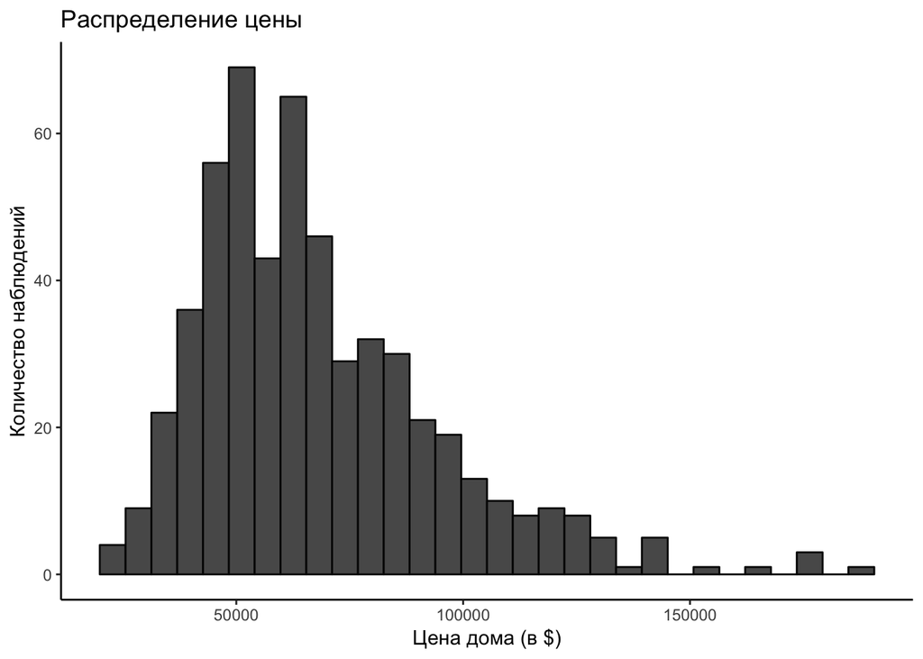

```r
theme_set(theme_classic())

ggplot(data = Housing) +
  scale_fill_brewer(palette = "Spectral") +
  geom_histogram(mapping = aes(x = price), color = "gray2") +
  labs(title = "Распределение цены", y = "Количество наблюдений", x = "Цена дома (в $)")
```

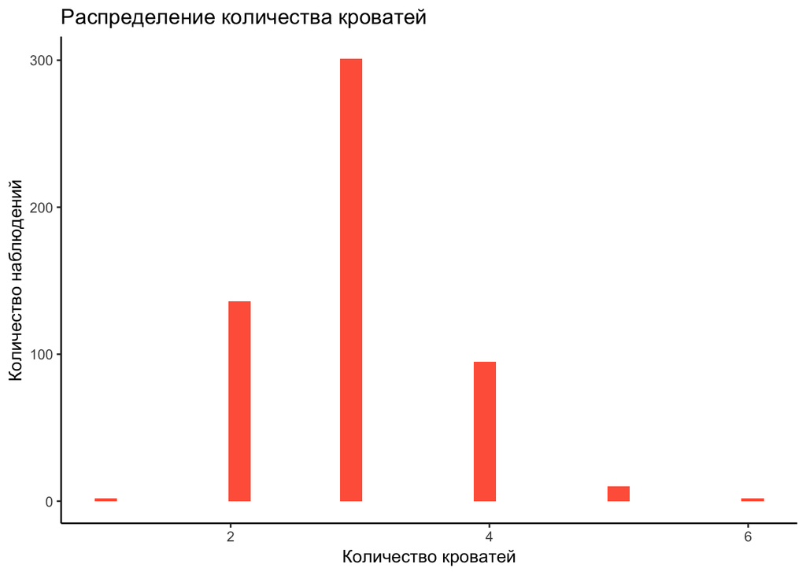

```r
ggplot(data = Housing) +
  scale_fill_brewer(palette = "Spectral") +
  geom_histogram(mapping = aes(x = bedrooms), fill = "tomato1") +
  labs(title = "Распределение количества кроватей", y = "Количество наблюдений",
  x = "Количество кроватей")
```

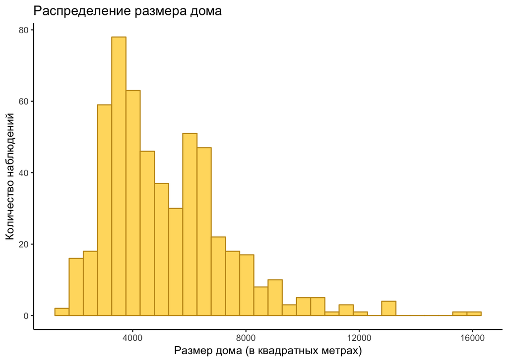

```r
ggplot(data = Housing) +
  scale_fill_brewer(palette = "Spectral") +
  geom_histogram(mapping = aes(x = lotsize), fill = "#FFDB6D", color = "#C4961A") +
  labs(title = "Распределение размера дома", y = "Количество наблюдений",
  x = "Размер дома (в квадратных метрах)")
```

Используем для предсказания цены дома `price` количество кроватей в нем `bedrooms`, а площадь дома `lotsize` будем использовать как инструмент.

Убедимся, что между ними есть связь, посчитав корреляцию. Заодно построим нехитрую корреляционную матрицу для всех численных переменных:

```r
cor(Housing$lotsize, Housing$bedrooms) # Считаем связь между переменной и инструментом
```

```
[1] 0.1518515
```

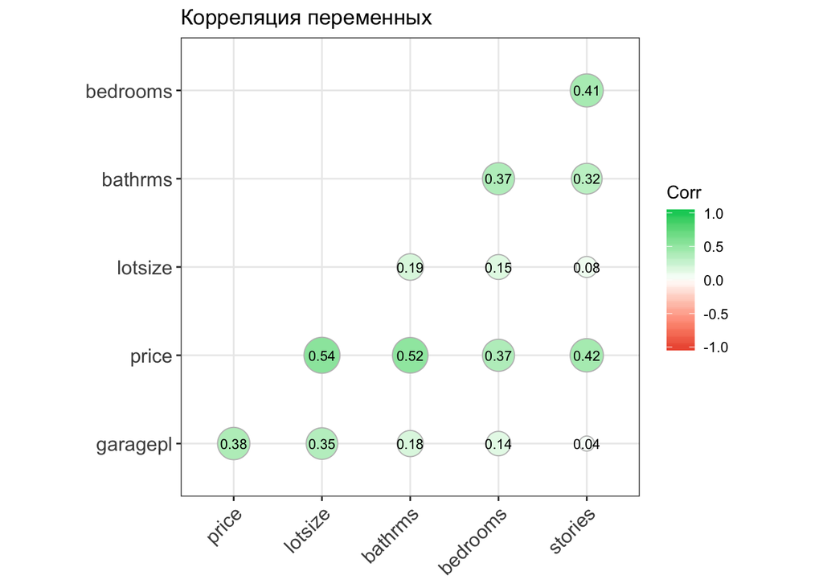

```r
housing_numeric = select_if(Housing, is.numeric) # Оставляем только численные переменные
cor_housing = cor(housing_numeric)
ggcorrplot(cor_housing, hc.order = TRUE,
           type = "lower",
           lab = TRUE,
           lab_size = 3,
           method = "circle",
           colors = c("tomato2", "white", "springgreen3"),
           title = "Корреляция переменных",
           ggtheme = theme_bw)
```

Действительно, между выбранными нами переменной и инструментом наблюдается корреляция, которая составляет 0.15.

Построим IV-регрессию, реализующую двухшаговый МНК, с помощью функции *ivreg*:

```r
iv1 = ivreg(price ~ bedrooms | lotsize, data = Housing)
summary(iv1)
```

```
Call:
ivreg(formula = price ~ bedrooms | lotsize, data = Housing)

Residuals:
    Min      1Q  Median      3Q     Max
-405887  -29318   -2568   82080  227978

Coefficients:
            Estimate Std. Error t value Pr(>|t|)
(Intercept)  -310751      99999  -3.108 0.001985 **
bedrooms      127773      33700   3.791 0.000167 ***
---
Signif. codes:  0 '***' 0.001 '**' 0.01 '*' 0.05 '.' 0.1 ' ' 1

Residual standard error: 88090 on 544 degrees of freedom
Multiple R-Squared: -9.864, Adjusted R-squared: -9.884
Wald test: 14.38 on 1 and 544 DF,  p-value: 0.0001665
```

Обратите внимание на синтаксис функции - он схож с простой регрессией. Первая переменная - зависимая, после знака `~` указываются регрессоры. После вертикальной черты `|` указываются инструментальные переменные. В поле *data* мы ссылаемся на данные, которые анализируем.

Чтобы полностью в этом убедиться, проведем тесты.

```r
summary(iv1, vcov = sandwich, diagnostics = TRUE)
```

```
Call:
ivreg(formula = price ~ bedrooms | lotsize, data = Housing)

Residuals:
    Min      1Q  Median      3Q     Max
-405887  -29318   -2568   82080  227978

Coefficients:
            Estimate Std. Error t value Pr(>|t|)
(Intercept)  -310751     104187  -2.983  0.00299 **
bedrooms      127773      35031   3.647  0.00029 ***

Diagnostic tests:
                 df1 df2 statistic  p-value
Weak instruments   1 544     11.48 0.000753 ***
Wu-Hausman         1 543    125.10  < 2e-16 ***
Sargan             0  NA        NA       NA
---
Signif. codes:  0 '***' 0.001 '**' 0.01 '*' 0.05 '.' 0.1 ' ' 1

Residual standard error: 88090 on 544 degrees of freedom
Multiple R-Squared: -9.864, Adjusted R-squared: -9.884
Wald test:  13.3 on 1 and 544 DF,  p-value: 0.0002904
```

Смотрим на раздел *Diagnostic tests*. Нас интересует тест на слабость инструментов, *Weak instruments*. Нулевая гипотеза заключается в том, что выбранный инструмент слабый. На любом разумном уровне значимости мы можем говорить о том, что гипотеза отвергается, а значит, выбранный инструмент неслабый. Следующий тест, *Wu-Hausman*, проверяет основную гипотезу о постоянстве МНК-оценок. Так как мы отвергаем основную гипотезу на любом разумном уровне значимости, оценки МНК не постоянны, то есть, присутствует эндогенность и МНК-оценки смещены, поэтому использование инструментов оправданно. *Тест Sargan*, проверяющий экзогенность инструментов, может применяться только в том случае, если количество инструментов превышает количество эндогенных переменных. В нашем случае данный тест не применим, так как мы выбрали только одну инструментальную переменную для одного регрессора.

Добавим еще одну инструментальную переменную, `bathrms`, содержащую информацию о количестве ванных комнат, и проведем *тест Sargan*.

```r
iv2 = ivreg(price ~ bedrooms | lotsize + bathrms, data = Housing)
summary(iv2)
```

```
Call:
ivreg(formula = price ~ bedrooms | lotsize + bathrms, data = Housing)

Residuals:
    Min      1Q  Median      3Q     Max
-190252  -22170    1905   30699  104905

Coefficients:
            Estimate Std. Error t value Pr(>|t|)
(Intercept)  -100061      18360  -5.450 7.65e-08 ***
bedrooms       56719       6164   9.201  < 2e-16 ***
---
Signif. codes:  0 '***' 0.001 '**' 0.01 '*' 0.05 '.' 0.1 ' ' 1

Residual standard error: 40580 on 544 degrees of freedom
Multiple R-Squared: -1.305, Adjusted R-squared: -1.31
Wald test: 84.67 on 1 and 544 DF,  p-value: < 2.2e-16
```

```r
summary(iv2, vcov = sandwich, diagnostics = TRUE)
```

```
Call:
ivreg(formula = price ~ bedrooms | lotsize + bathrms, data = Housing)

Residuals:
    Min      1Q  Median      3Q     Max
-190252  -22170    1905   30699  104905

Coefficients:
            Estimate Std. Error t value Pr(>|t|)
(Intercept)  -100061      20264  -4.938 1.05e-06 ***
bedrooms       56719       6894   8.228 1.42e-15 ***

Diagnostic tests:
                 df1 df2 statistic  p-value
Weak instruments   2 543     48.79  < 2e-16 ***
Wu-Hausman         1 543    135.37  < 2e-16 ***
Sargan             1  NA     24.96 5.85e-07 ***
---
Signif. codes:  0 '***' 0.001 '**' 0.01 '*' 0.05 '.' 0.1 ' ' 1

Residual standard error: 40580 on 544 degrees of freedom
Multiple R-Squared: -1.305, Adjusted R-squared: -1.31
Wald test: 67.69 on 1 and 544 DF,  p-value: 1.417e-15
```

## На Stata

Будем работать с набором данных, содержащих информацию о зарплатах. Загрузим данные, посмотрим их строение.

```stata
webuse educwages
describe
```

```stata
ivregress 2sls wages union (education = meducation feducation)
```

Проведем тесты на качество подбора инструментов.

```stata
estat endog
```

Проведем *тесты Sargan и Basmann*.

```stata
estat overid
```

## На Python

Разберем применение метода инструментальных переменных на Python. Загружаем необходимые библиотеки:

```python
import pandas as pd # Библиотека pandas для работы с данными
import seaborn as sns # Библиотека seaborn для визуализации
import matplotlib.pyplot as plt # Библиотека matplotlib для визуализации
from sklearn.preprocessing import StandardScaler # Импортируем StandartScaler
import statsmodels.api as sm # Для двухшагового МНКы
```

Загружаем данные и исследуем их строение:

```python
url = "https://raw.githubusercontent.com/arunk13/MSDA-Assignments/master/IS607Fall2015/Assignment3/student-mat.csv"
df = pd.read_csv(url,
                header=0,
                sep = ";")
print(df.head(2))
```

```
  school sex  age address famsize ... health  absences  G1 G2 G3
0     GP   F   18       U     GT3 ...      3         6   5  6  6
1     GP   F   17       U     GT3 ...      3         4   5  5  6

[2 rows x 33 columns]
```

Изучим зависимость успеваемости ученика `G3` от времени, которое он тратит на учебу `studytime` и его свободного времени `freetime`, а в качестве инструмента для свободного времени используем `traveltime`, время, которое он тратит на поездку до учебы. Логика здесь такая: чем больше времени ученик тратит на дорогу, тем меньше у него времени остается на учебу, а значит, меньше вероятность получить хорошую оценку. Преобразуем выбранные переменные:

```python
grade = df.loc[:, 'G3']
freetime = df.loc[:, 'freetime']
traveltime = df.loc[:, 'traveltime']
studtytime = df.loc[:, 'studytime']
```

Проверим корреляцию переменной `freetime` и подобранного инструмента `traveltime`, построив диаграмму корреляции всех признаков:

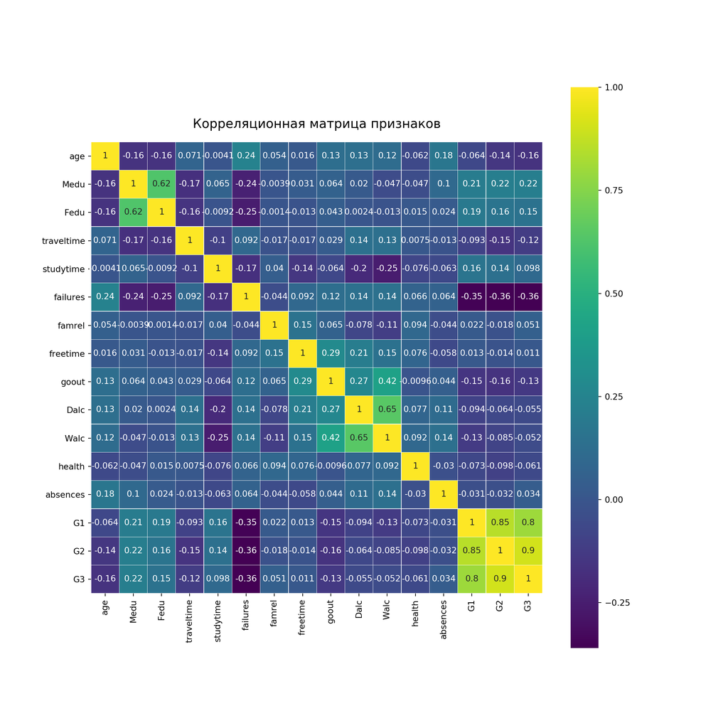

```python
colormap = plt.cm.viridis
corr = df.corr()
plt.figure(figsize=(12,12))
plt.title('Корреляционная матрица признаков', y=1.02, size=15)
sns.heatmap(corr,linewidths=0.1,vmax=1.0, square=True, cmap=colormap, linecolor='white', annot=True)
```

Проведем двухшаговый МНК при помощи функции IV2SLS из пакета **linearmodels**. Чтобы использовать ее, надо установить пакет **linearmodels**. Для этого, если он еще не установлен, нужно выполнить следующую команду в командной строке: `pip install linearmodels`. Убедившись, что она установлена, импортируем нужные библиотеки и приступаем к двухшаговому МНК:

```python
from linearmodels import IV2SLS
ivmod = IV2SLS.from_formula('grade ~ 1 + studytime  + [freetime ~ traveltime]', df)
res_2sls = ivmod.fit()
print(res_2sls.summary)
```

```
                          IV-2SLS Estimation Summary
==============================================================================
Dep. Variable:                  grade   R-squared:                     -11.195
Estimator:                    IV-2SLS   Adj. R-squared:                -11.257
No. Observations:                 395   F-statistic:                    0.6739
Date:                Mon, Sep 16 2019   P-value (F-stat)                0.7139
Time:                        16:03:21   Distribution:                  chi2(2)
Cov. Estimator:                robust

                             Parameter Estimates
==============================================================================
            Parameter  Std. Err.     T-stat    P-value    Lower CI    Upper CI
------------------------------------------------------------------------------
Intercept     -46.671     86.188    -0.5415     0.5882     -215.60      122.25
studytime      3.1982     4.2508     0.7524     0.4518     -5.1332      11.530
freetime       15.632     24.041     0.6502     0.5155     -31.488      62.752
==============================================================================

Endogenous: freetime
Instruments: traveltime
Robust Covariance (Heteroskedastic)
Debiased: False
```

Проверим качество подбора инструментов с помощью тестов. *Durbin тест*:

```python
res_2sls.durbin()
```

```
Durbin test of exogeneity
H0: All endogenous variables are exogenous
Statistic: 4.5741
P-value: 0.0325
Distributed: chi2(1)
WaldTestStatistic, id: 0x115288518
```

*Wu-Hausman тест*:

```python
res_2sls.wu_hausman()
```

```
Wu-Hausman test of exogeneity
H0: All endogenous variables are exogenous
Statistic: 4.5808
P-value: 0.0330
Distributed: F(1,391)
WaldTestStatistic, id: 0x1c2d6c91d0
```